# Predicting Barbell Exercise Training Technique

### Executive Summary

Barbell usage data was modeled to predict proper exercise training technique. Multiple statistical models were evaluated and the random forest model was selected. Out of sample accuracy is estimated to be 0.984. Test set predictions are: B A C A A E D B A A B C B A E E A B B B.

Note: All of the code used to perform this analysis is embedded in the associated R markdown file. However, the modeling could not be executed from the R Markdown file due to the computing time required. The pertinent results from model execution are included in the embedded R code comments as well as the text of the R markdown document and html document.

### Data Description

Using devices such as Jawbone Up, Nike FuelBand, and Fitbit it is now possible to collect a large amount of data about personal activity relatively inexpensively. These type of devices are part of the quantified self movement - a group of enthusiasts who take measurements about themselves regularly to improve their health, to find patterns in their behavior, or because they are tech geeks. One thing that people regularly do is quantify how much of a particular activity they do, but they rarely quantify how well they do it. In this project, your goal will be to use data from accelerometers on the belt, forearm, arm, and dumbell of 6 participants. They were asked to perform barbell lifts correctly and incorrectly in 5 different ways. More information is available from the website here: http://groupware.les.inf.puc-rio.br/har (see the section on the Weight Lifting Exercise Dataset). The training data for this project are available here: https://d396qusza40orc.cloudfront.net/predmachlearn/pml-training.csv The test data are available here: https://d396qusza40orc.cloudfront.net/predmachlearn/pml-testing.csv

### Exploratory Analysis

Visual inspection of the data revealed many NA values so a function was written to identify columns of all-NA values in the testing set. One hundred such columns were identified. Six variables were visually identified to be unrelated to the outcome and thus unworthy of prediction. A variable in the testing data, unrelated to any variable in the training set, was identified. A check of near zero variance was performed on all variables; none were identified. A categorical variable was identified for transformation into dummy variables

### Pre-Processing and Dimension Reduction

Per the exploratory analysis, one hundred all-NA variables were removed and six variables deemed unworthy of prediction were removed from both training and testing sets. The user_name categorical variable was converted into five dummy variables, using 0/1 coding. The problem_id variable was removed from the test set, and the outcome variable was removed from the training set for further pre-processing and prediction.

Further pro-processing was performed to reduce skew (BoxCox method) , center and scale, reduce outlier influence (spatialSign method) and remove collinearity (pca method) in the remaining predictor variables.

The result of the above pre-processing resulted in a dimension reduction from 159 variables of raw data to 25 variables of predictors

### Exploratory Modeling

Several modeling methods were used in “exploratory” modeling. A linear discriminate analysis (lda) model yielded poor prediction accuracy. A support vector machine (radialSVM) model took too long to run and was terminated. A gradient boosted regression model (gbm) may have provided good accuracy but required more computing resources than available (memory and time).

### Model Selection

A random forest model overcame the computing limitations of support vector machine models and gradient boosted regression models, and provided better accuracy than linear discriminate analysis modeling.

Repeated cross validation sampling was employed, with 5 repeats of 10 fold cross validation, and a tuning length of 10.

### Test Set Prediction

Applying our random forest model to the test set yields outcomes of:

B A C A A E D B A A B C B A E E A B B B

### Figure 1:

Estimated Out-of-Sample Accuracy of Random Forest Model Using 5 Repeats of 10 Fold Cross Validation, and a Tuning Length of 10

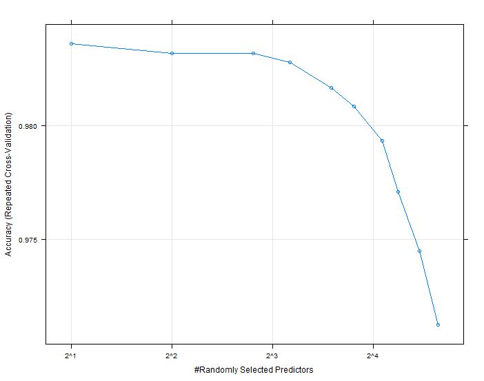